# Testing many classification algorithms

## Introduction

Comparing several classifications algorithms. For this test I will use banknote authentication data to fit logistics regression model and evaluate performance of LDA, QDA and KNN classifiers.

## Logistic Regression

```r
# Get information from dataset
banknote <- read.table("data\\data_banknote_authentication.txt", sep = ",")
# Naming the columns
colnames(banknote) <- c("variance","skewness" , "curtosis", "entropy", "classoutcome")

# Fitting logistic regression model.
logreg.mdl <- glm(classoutcome ~ ., data = banknote, family = binomial)
# Model summary
summary(logreg.mdl)
```

```
##
## Call:
## glm(formula = classoutcome ~ ., family = binomial, data = banknote)
##
## Deviance Residuals:
##      Min        1Q    Median        3Q       Max
## -1.70001   0.00000   0.00000   0.00029   2.24614
##
## Coefficients:
##             Estimate Std. Error z value Pr(>|z|)
## (Intercept)   7.3218     1.5589   4.697 2.64e-06 ***
## variance     -7.8593     1.7383  -4.521 6.15e-06 ***
## skewness     -4.1910     0.9041  -4.635 3.56e-06 ***
## curtosis     -5.2874     1.1612  -4.553 5.28e-06 ***
## entropy      -0.6053     0.3307  -1.830   0.0672 .
## ---
## Signif. codes:  0 '***' 0.001 '**' 0.01 '*' 0.05 '.' 0.1 ' ' 1
##
## (Dispersion parameter for binomial family taken to be 1)
##
##     Null deviance: 1885.122  on 1371  degrees of freedom
## Residual deviance:   49.891  on 1367  degrees of freedom
## AIC: 59.891
##
## Number of Fisher Scoring iterations: 12
```

```r
# Predicting the model
logreg.pred <- predict(logreg.mdl, newdata = banknote[, 1:4], type = "response")

# Converting the probabilities into 0 or 1
logreg.out  <- ifelse(logreg.pred>0.5, 1, 0)

# Matrix Confusion
mconf.logres <- table(Predict=logreg.out, original=banknote$classoutcome)
mconf.logres
```

```
##        original
## Predict   0   1
##       0 757   6
##       1   5 604
```

```r
# sensitivity
mconf.logres[2,2] / sum(mconf.logres[,2])
```

```
## [1] 0.9901639
```

```r
# specificity
mconf.logres[1,1] / sum(mconf.logres[,1])
```

```
## [1] 0.9934383
```

```r
# Error rate
mean(logreg.out!=banknote$classoutcome)
```

```
## [1] 0.008017493
```

**The independent variables variance, skewness and kurtosis seem to be the most significant for the model, all have a very low p value, while the entropy variable has a value above 0.05.** **The results of the performance were excellent, because we are using the same dataset to create and predict the model, this makes all indicators very good. Sensitivity and Specificity were very high as well as acuracy. And the error rate was very low.**

## LDA and QDA

```r
# Fitting lda/qda model.
lda.mdl <- lda(classoutcome ~ ., data = banknote)
qda.mdl <- qda(classoutcome ~ ., data = banknote)

# Predicting on entire dataset
lda.pred <- predict(lda.mdl, newdata = banknote)
qda.pred <- predict(qda.mdl, newdata = banknote)

# Confusion Matrix
mconf.lda <- table(predict = lda.pred$class, original=banknote$classoutcome)
mconf.qda <- table(predict = qda.pred$class, original=banknote$classoutcome)

# Printing Matrixes
mconf.lda
```

```
##        original
## predict   0   1
##       0 730   0
##       1  32 610
```

```r
mconf.qda
```

```
##        original
## predict   0   1
##       0 742   0
##       1  20 610
```

```r
#### sensitivity
## LDA
mconf.lda[2,2] / sum(mconf.lda[,2])
```

```
## [1] 1
```

```r
## QDA
mconf.qda[2,2] / sum(mconf.qda[,2])
```

```
## [1] 1
```

```r
#### specificity
## LDA
mconf.lda[1,1] / sum(mconf.lda[,1])
```

```
## [1] 0.9580052
```

```r
## QDA
mconf.qda[1,1] / sum(mconf.qda[,1])
```

```
## [1] 0.9737533
```

```r
#### Error rate
## LDA
mean(lda.pred$class!=banknote$classoutcome)
```

```
## [1] 0.02332362
```

```r
## QDA
mean(qda.pred$class!=banknote$classoutcome)
```

```
## [1] 0.01457726
```

**The LDA and QDA classifiers showed slightly better values of sensitivity than logistic regression, all positive values were correctly predicted, so no true event was missed. However for specificity and error rate the numbers were worse. Indicating a higher number of false positives than in the previous classifier.**

## KNN

```r
idxk = c(1, 7, 23)


for (i in idxk) {
  cat("**** KNN with K =", i, "****","\n")
  knn.pred <- knn(train = banknote[1:4], test = banknote[,1:4], cl = banknote$classoutcome, k = i )


  print("Confusion Matrix")
  mconf.knn <- table(predict=knn.pred, original = banknote$classoutcome)
  print(mconf.knn)

  print("Sensitivity")
  print(mconf.knn[2,2] / sum(mconf.knn[,2]))

  print("specificity")
  print(mconf.knn[1,1] / sum(mconf.knn[,1]))

  print("Error Rate")
  print(mean(knn.pred!=banknote$classoutcome))

}
```

```
## **** KNN with K = 1 ****
## [1] "Confusion Matrix"
##        original
## predict   0   1
##       0 762   0
##       1   0 610
## [1] "Sensitivity"
## [1] 1
## [1] "specificity"
## [1] 1
## [1] "Error Rate"
## [1] 0
## **** KNN with K = 7 ****
## [1] "Confusion Matrix"
##        original
```

[output cut: 21 more lines]

**KNN had 100% accuracy, sensitivity = 1 and specificity = 1 for K = 1 and K = 7. In the case of K = 1 there is no surprise since in this case we are considering only 1 neighbor, of course in this case the error rate it would be 0 in the training dataset. However in this case we will have a low bias and a high variance. K = 23 has very good indicators compared to the other methods above.**

## Comparing test errors of logistic regression, LDA, QDA and KNN

Bootstrap validation function

```r
bootrescomparison <- function (ntries, inpmethod, nbvar=4) {

  dftemp <- NULL

  for (itries in 1:ntries) {
    bdata     <- sample(nrow(banknote), nrow(banknote), replace = TRUE)
    btrain    <- banknote[bdata,]

    btrain$classoutcome <- as.factor(btrain$classoutcome)

    btest     <- banknote[-bdata,]
    btest.out <- banknote[-bdata,"classoutcome"]

    for (imethod in inpmethod) {
      gen.predi <- NULL
      if (imethod == "lr") {

        gen.model <- glm(classoutcome ~ ., data = btrain, family = binomial)
        gen.predi <- ifelse(predict(gen.model, btest, type = "response")>0.5,1,0)
      }
      else if (imethod == "lda") {
        gen.model <- lda(classoutcome ~ ., data = btrain, family = binomial)
        gen.predi <- predict(gen.model, btest)$class
      }
      else if (imethod == "qda") {
        gen.model <- lda(classoutcome ~ ., data = btrain, family = binomial)
        gen.predi <- predict(gen.model, btest)$class
      }
      ## The others are KNN 1..101
      else if (substr(imethod,1,1)=="k")
      {

        # Get numeric part of imethod. i.e. "K40" -> "40"
        i <- as.numeric(substr(imethod, 2, nchar(imethod)))
        gen.predi <- knn(train = btrain[,1:4], test = btest[,1:4], cl = btrain$classoutcome, k = i )

      }

      else if (imethod == "nb") {
        cols          <- colnames(btrain[,1:nbvar])
        cols[nbvar+1] <- c("classoutcome")
        gen.model <- naiveBayes(classoutcome ~ ., data = btrain[,cols])
        gen.predi <- predict(gen.model, btest[,1:nbvar])
      }

      if (!is.null(gen.predi)) {

        # Confusion Matrix
        gen.mconf <- table(predict=gen.predi, truth=btest.out)
        gen.mconf

        # sensitivity
        sen <- gen.mconf[2,2] / sum(gen.mconf[,2])
        # specificity
        spe <- gen.mconf[1,1] / sum(gen.mconf[,1])
        # Error rate
        err       <- mean(gen.predi!=btest.out)

        dftemp <- rbind(dftemp, data.frame(method=imethod, sensitivity=sen, specificity=spe, error=err))

        }

      }

  }
  dftemp

}
```

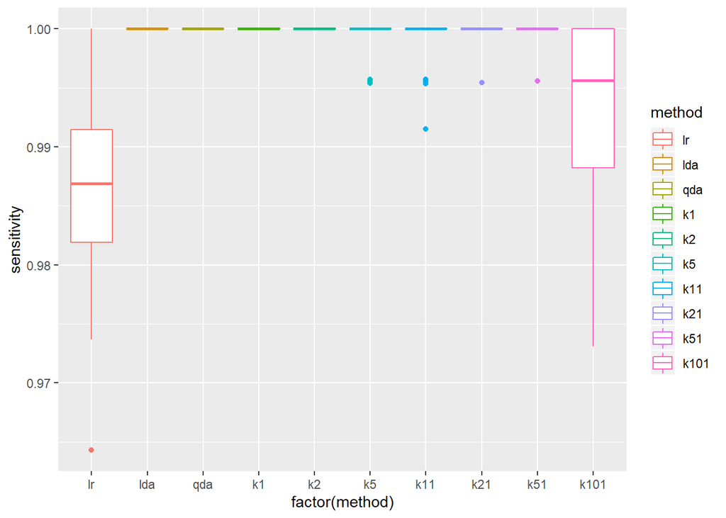

```r
# Select the methods
method <- c("lr", "lda", "qda", "k1", "k2","k5","k11","k21","k51","k101")

# Get the result of the function
df.out <- bootrescomparison (50, method, 2)

# Plot the results
old.par <- par(mfrow=c(1,3))
ggplot(df.out, aes(x=factor(method), y=sensitivity, colour = method)) + geom_boxplot()
```

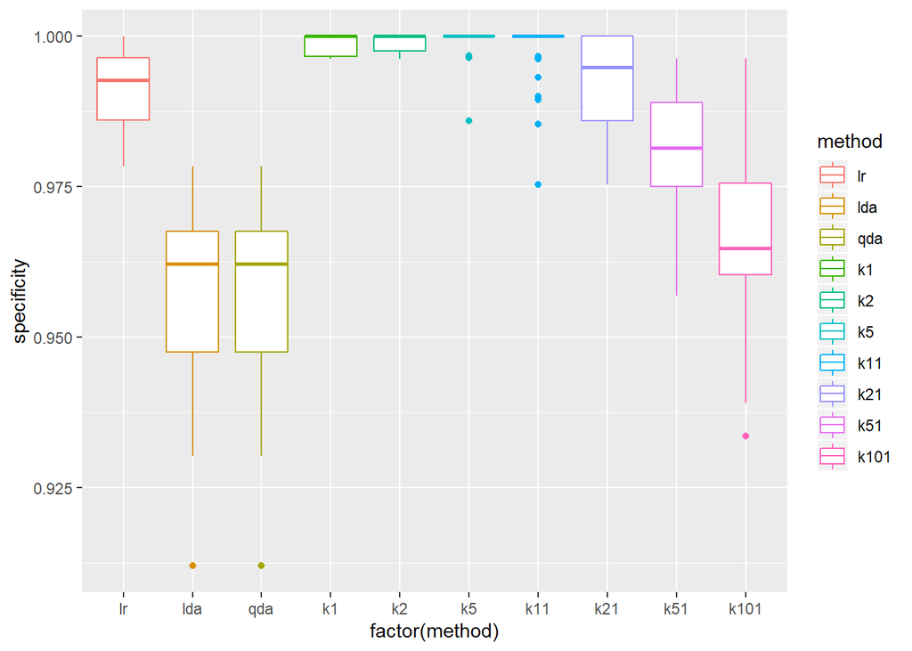

```r
ggplot(df.out, aes(x=factor(method), y=specificity, colour = method)) + geom_boxplot()
```

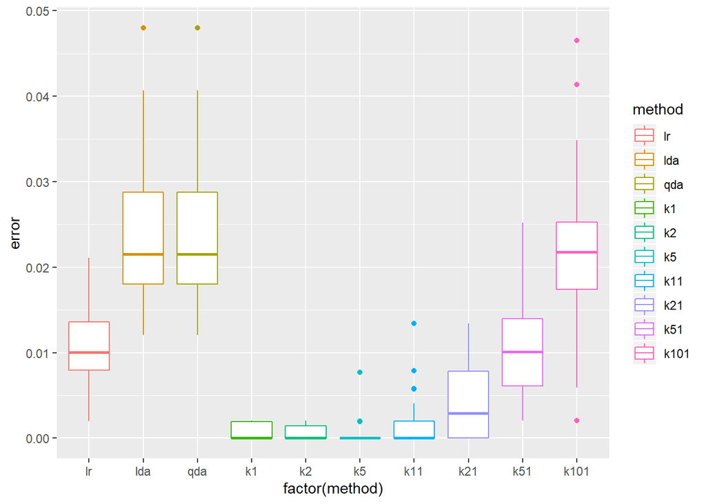

```r
ggplot(df.out, aes(x=factor(method), y=error, colour = method)) + geom_boxplot()
```

```r
par(old.par)
```

**Considering the several tests performed, it is possible to verify that the logistic regression and knn presented the best performances. LDA and QDA had good performance in sensitivity, but they had worse results in specificty and error rate. It is also worth commenting that Knn with K> 21 did not perform well.**

## Naive Bayes classifier

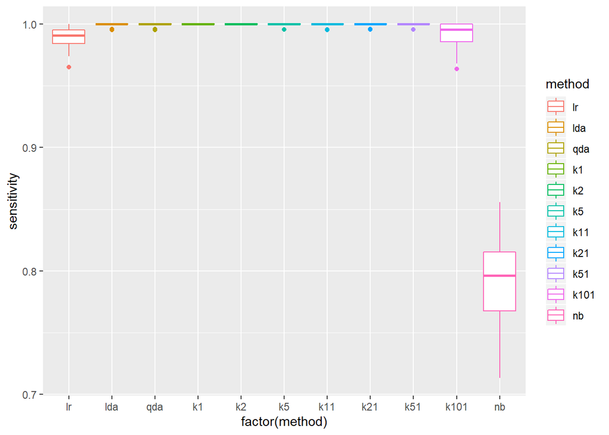

```r
ntries <- 50

# Adding NaiveBayes method
method <- c("lr", "lda", "qda", "k1", "k2","k5","k11","k21","k51","k101", "nb")

# Get the results
df.out <- bootrescomparison(ntries, method)

# Plot the methods
ggplot(df.out, aes(x=factor(method), y=sensitivity, colour = method)) + geom_boxplot()
```

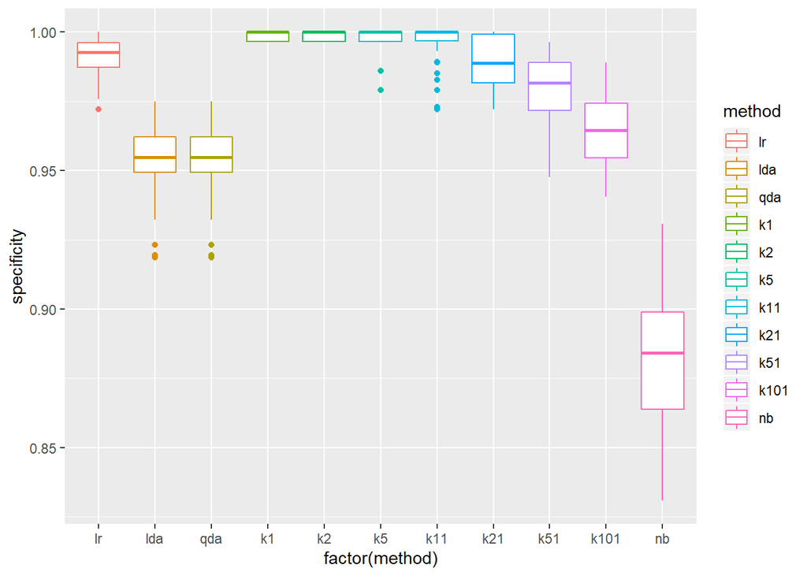

```r
ggplot(df.out, aes(x=factor(method), y=specificity, colour = method)) + geom_boxplot()
```

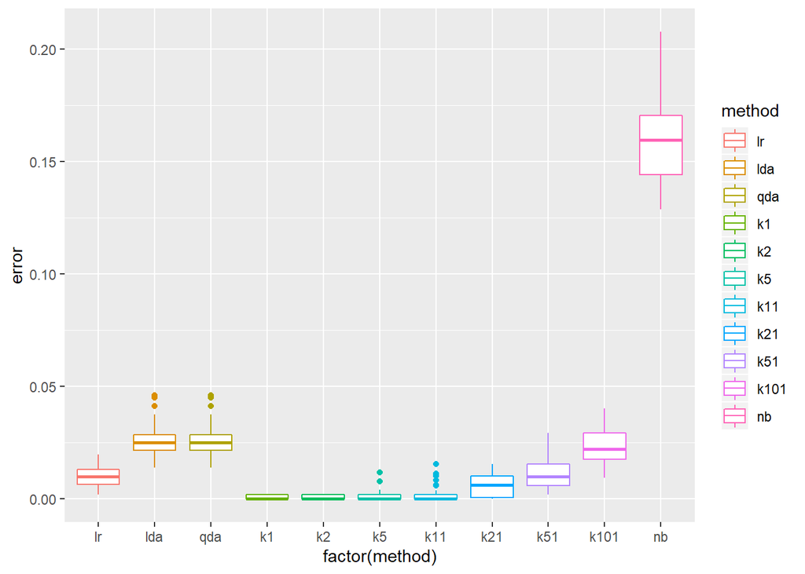

```r
ggplot(df.out, aes(x=factor(method), y=error, colour = method)) + geom_boxplot()
```

**The plots showed that Naive Bayes is not the best option to use as a classifier in this dataset.** **The Naive Bayes classifier did not perform well, it had a worse rating on practically all metrics when compared to other methods, especially with respect to the error rate that is very far from the others.**

```r
bdata.tmp     <- sample(nrow(banknote), nrow(banknote), replace = TRUE)
btrain.tmp    <- banknote[bdata.tmp,]

btrain.tmp$classoutcome <- as.factor(btrain.tmp$classoutcome)

btest.tmp     <- banknote[-bdata.tmp,]
btest.out.tmp <- banknote[-bdata.tmp,"classoutcome"]

nb.model <- naiveBayes(classoutcome ~ variance + skewness, data = btrain.tmp)
nb.predi <- predict(nb.model, btest.tmp[,1:4])

# NaiveBayes metrics.
assess.prediction(btest.out.tmp, nb.predi)
```

```
## Total cases that are not NA: 492
## Correct predictions (accuracy): 437(88.8%)
## TP, TN, FP, FN, P, N: 199 238 29 26 225 267
## TPR (sensitivity)=TP/P: 88.4%
## TNR (specificity)=TN/N: 89.1%
## PPV (precision)=TP/(TP+FP): 87.3%
## FDR (false discovery)=1-PPV: 12.7%
## FPR =FP/N=1-TNR: 10.9%
```